# **Challenge - COVID Database**

**Costa Rica Big Data School - Grupo 2**

## **Step 1. Load database**

Load the database from a Drive folder.

```python
%%capture
!unzip -q '/content/drive/MyDrive/CHALLENGE_GRUPO2/covid.zip'
```

## **Step 2: Process images**

We will use Tensorflow `img_to_array` processor to convert the .png files to `np.arrays`.

```python
import os
from tensorflow.keras.preprocessing.image import img_to_array #Import the function directly
import numpy as np
import cv2


#preparar función para procesar las imágenes

def process_image(image_path):
  img = cv2.imread(image_path) #read image path
  img = cv2.cvtColor(img, cv2.COLOR_BGR2GRAY) #convert it into grayscale
  img_array = img_to_array(img) #convert it into an array
  resized_img = cv2.resize(img_array, (100, 100)) #resize into a 100 x 100px
  normalized_img = resized_img / 255.0  #normalize the arrays
  return normalized_img


#PROCESAR IMÁGENES DE COVID
covid = [] #create an empty variable to store the arrays


for filename in os.listdir('/content/COVID'): #process every image
  if filename.endswith(".png"):
    image_path = os.path.join('/content/COVID', filename) #save image path
    processed_image = process_image(image_path) #process the image
    covid.append(processed_image) #store it into the "covid" variable


covid = np.array(covid) #convert it into an array



#PROCESAR IMÁGENES DE NO-COVID
no_covid = [] #create an empty variable to store the arrays


for filename in os.listdir('/content/non-COVID'): #process every image
  if filename.endswith(".png"):
    image_path = os.path.join('/content/non-COVID', filename) #save image path
    processed_image = process_image(image_path) #process the image
    no_covid.append(processed_image) #store it into the "covid" variable


no_covid = np.array(no_covid) #convert it into an array

print(covid.shape)
print(no_covid.shape)
```

```
(1252, 100, 100)
(1229, 100, 100)
```

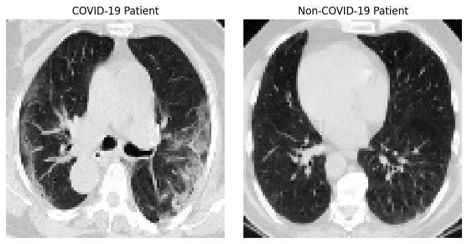

```python
import matplotlib.pyplot as plt
import matplotlib.cm as cm

# Suponiendo que 'covid' y 'ncovid' son arrays de NumPy previamente cargados
# y que cada uno tiene la forma adecuada para estos indices
# Aquí utilizamos el décimo elemento en el primer índice, todas las filas, y todas las columnas
covid_patient = np.flip(covid[9, :, :], axis=1)
noncovid_patient = np.flip(no_covid[9,:,:],axis=1)

# Create a figure with two subplots side by side
fig, axes = plt.subplots(1, 2, figsize=(8, 4))

# Plot the COVID-19 patient on the left subplot
axes[0].imshow(covid_patient, cmap=cm.gray)
axes[0].set_title("COVID-19 Patient")
axes[0].axis('off')

# Plot the non-COVID-19 patient on the right subplot
axes[1].imshow(noncovid_patient, cmap=cm.gray)
axes[1].set_title("Non-COVID-19 Patient")
axes[1].axis('off')

# Adjust spacing between subplots
plt.tight_layout()

# Display the figure
plt.show()
```

## **Step 3. Data sampling**

1. Flatten the arrays: (nrow, 100, 100) to (nrow, 10000)
2. Create an output column *(0 = no covid, 1 = covid)*
3. Split the datasets into **X** (pixels), and **Y** (output)
4. Stratified sampling *(to guarantee representative data in both training and test sets)* into a training set (80%) and a test set (20%).

```python
# Add a column of 1s to the covid array
covid_with_label = np.c_[covid.reshape(covid.shape[0], -1), np.ones(covid.shape[0])[:, np.newaxis]]

# Add a column of 0s to the no_covid array
nocovid_with_label = np.c_[no_covid.reshape(no_covid.shape[0], -1), np.zeros(no_covid.shape[0])[:, np.newaxis]]

# Concatenate the two arrays vertically
df = np.concatenate((covid_with_label, nocovid_with_label), axis=0)


#stratified sampling
from sklearn.model_selection import StratifiedShuffleSplit

# Assuming the last column of 'df' contains the labels (1 for COVID, 0 for non-COVID)
X = df[:, :-1]  # Features (image data)
y = df[:, -1]   # Labels

# Perform stratified sampling
sss = StratifiedShuffleSplit(n_splits=1, test_size=0.2, random_state=42)  # Adjust test_size as needed
for train_index, test_index in sss.split(X, y):
  X_train, X_test = X[train_index], X[test_index]
  y_train, y_test = y[train_index], y[test_index]

# Now you have stratified samples in X_train, X_test, y_train, and y_test

print("Se hizo un muestreo estratificado")
print(f'Training set (80%): {X_train.shape}')
print(f'Test set (20%): {X_test.shape}')
```

```
Se hizo un muestreo estratificado
Training set (80%): (1984, 10000)
Test set (20%): (497, 10000)
```

## **Step 4: Train an Artificial Neural Network**

1. Train the NN with the training set.
2. Predict the test set.
3. Plot a confusion matrix.
4. Report accuracy $\left(\frac{TP + TN}{TP + TN + FP + FN}\right)$

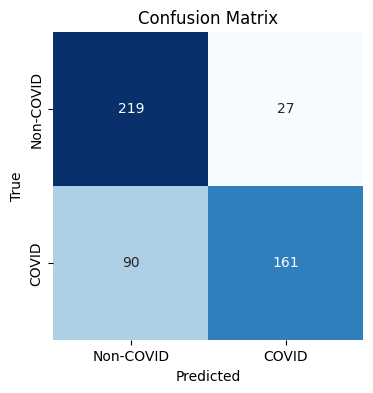

```
The accuracy of the Artifical Neural Network is 0.76
```

```python
from tensorflow.keras.models import Sequential
from tensorflow.keras.layers import Dense, Flatten, Dropout



NN = Sequential([
    Dense(128, activation='relu'),
    Dense(64, activation='relu'),
    Flatten(), # Flatten the output before the final Dense layer
    Dropout(0.5),
    Dense(1, activation='sigmoid')
])

NN.compile(optimizer='adam', loss='binary_crossentropy', metrics=['accuracy'])

NN.fit(X_train, y_train, epochs=10, batch_size=32, validation_data=(X_test, y_test))



from sklearn.metrics import confusion_matrix
import seaborn as sns

# Predict on the test set
y_pred = NN.predict(X_test)
y_pred_classes = (y_pred > 0.5).astype(int)  # Convert probabilities to class labels (0 or 1)

# Create confusion matrix
cm = confusion_matrix(y_test, y_pred_classes)

# Plot the confusion matrix
plt.figure(figsize=(4, 4))
sns.heatmap(cm, annot=True, fmt='d', cmap='Blues', cbar=False,
            xticklabels=['Non-COVID', 'COVID'], yticklabels=['Non-COVID', 'COVID'])
plt.xlabel('Predicted')
plt.ylabel('True')
plt.title('Confusion Matrix')
plt.show()

NN_ac = round((cm[0,0]+cm[1,1])/(cm[0,0]+cm[1,1]+cm[0,1]+cm[1,0]),2)

print(f'The accuracy of the Artifical Neural Network is {NN_ac}')
```

## **Step 5: Train a Support Vector Machine**

1. Train the SVM with the training set.
2. Predict the test set.
3. Plot a confusion matrix.
4. Report accuracy $\left(\frac{TP + TN}{TP + TN + FP + FN}\right)$

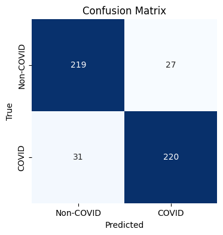

```
The accuracy of the Support Vector Machine is 0.88
```

```python
from sklearn import svm


SVM = svm.SVC()
SVM.fit(X_train, y_train)



y_pred = SVM.predict(X_test)
y_pred_classes = (y_pred > 0.5).astype(int)  # Convert probabilities to class labels (0 or 1)

# Create confusion matrix
cm = confusion_matrix(y_test, y_pred_classes)

# Plot the confusion matrix
plt.figure(figsize=(4, 4))
sns.heatmap(cm, annot=True, fmt='d', cmap='Blues', cbar=False,
            xticklabels=['Non-COVID', 'COVID'], yticklabels=['Non-COVID', 'COVID'])
plt.xlabel('Predicted')
plt.ylabel('True')
plt.title('Confusion Matrix')
plt.show()

SVM_ac = round((cm[0,0]+cm[1,1])/(cm[0,0]+cm[1,1]+cm[0,1]+cm[1,0]),2)

print(f'The accuracy of the Support Vector Machine is {SVM_ac}')
```

## **Step 6: Train Random Forest**

1. Train the RF with the training set.
2. Predict the test set.
3. Plot a confusion matrix.
4. Report accuracy $\left(\frac{TP + TN}{TP + TN + FP + FN}\right)$

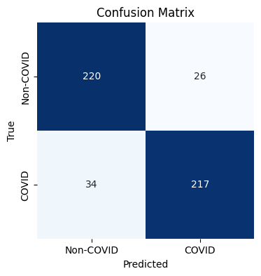

```
The accuracy of the Random Forest is 0.88
```

```python
from sklearn.ensemble import RandomForestClassifier

# Initialize the Random Forest Classifier
RF = RandomForestClassifier(n_estimators=100, random_state=42)  # You can adjust hyperparameters here

# Train the model
RF.fit(X_train, y_train)

y_pred = RF.predict(X_test)
y_pred_classes = (y_pred > 0.5).astype(int)  # Convert probabilities to class labels (0 or 1)

# Create confusion matrix
cm = confusion_matrix(y_test, y_pred_classes)

# Plot the confusion matrix
plt.figure(figsize=(4, 4))
sns.heatmap(cm, annot=True, fmt='d', cmap='Blues', cbar=False,
            xticklabels=['Non-COVID', 'COVID'], yticklabels=['Non-COVID', 'COVID'])
plt.xlabel('Predicted')
plt.ylabel('True')
plt.title('Confusion Matrix')
plt.show()

RF_ac = round((cm[0,0]+cm[1,1])/(cm[0,0]+cm[1,1]+cm[0,1]+cm[1,0]),2)

print(f'The accuracy of the Random Forest is {RF_ac}')
```

## **Step 7: Train Logistic Regression**

1. Train the LR with the training set.
2. Predict the test set.
3. Plot a confusion matrix.
4. Report accuracy $\left(\frac{TP + TN}{TP + TN + FP + FN}\right)$

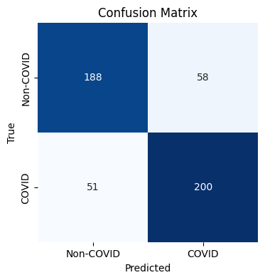

```
The accuracy of the Logistic Regression is 0.78
```

```python
from sklearn.linear_model import LogisticRegression

LR = LogisticRegression()
LR.fit(X_train, y_train)


y_pred = LR.predict(X_test)
y_pred_classes = (y_pred > 0.5).astype(int)  # Convert probabilities to class labels (0 or 1)

# Create confusion matrix
cm = confusion_matrix(y_test, y_pred_classes)

# Plot the confusion matrix
plt.figure(figsize=(4, 4))
sns.heatmap(cm, annot=True, fmt='d', cmap='Blues', cbar=False,
            xticklabels=['Non-COVID', 'COVID'], yticklabels=['Non-COVID', 'COVID'])
plt.xlabel('Predicted')
plt.ylabel('True')
plt.title('Confusion Matrix')
plt.show()

LR_ac = round((cm[0,0]+cm[1,1])/(cm[0,0]+cm[1,1]+cm[0,1]+cm[1,0]),2)

print(f'The accuracy of the Logistic Regression is {LR_ac}')
```

## **Step 8: Results**

```python
import pandas as pd

results = pd.DataFrame({
    'Model': ['Neural Network', 'Support Vector Machine', 'Random Forest', 'Logistic Regression'],
    'Accuracy': [NN_ac, SVM_ac, RF_ac, LR_ac]
})

results
```

|  | Model | Accuracy |
| --- | --- | --- |
| 0 | Neural Network | 0.76 |
| 1 | Support Vector Machine | 0.88 |
| 2 | Random Forest | 0.88 |
| 3 | Logistic Regression | 0.78 |

## **Step 9: k-fold Cross Validation**

k = 10

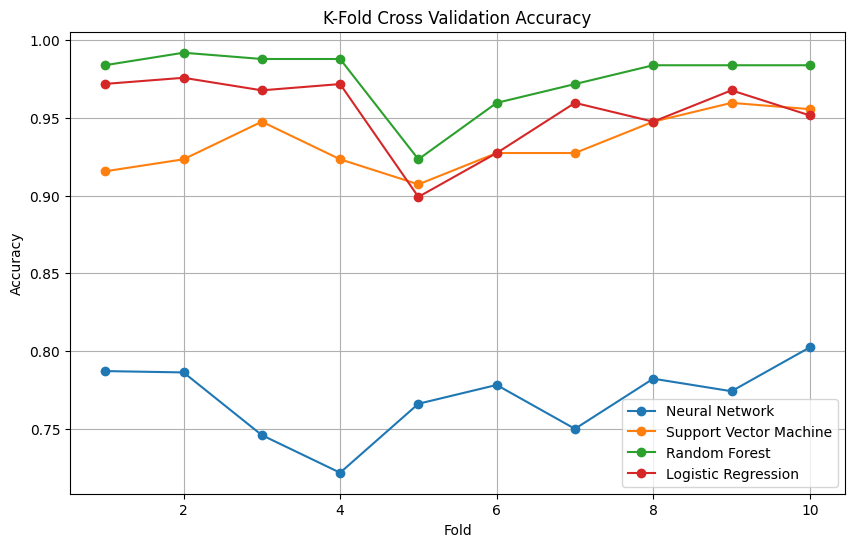

```python
from sklearn.model_selection import KFold
from sklearn.metrics import accuracy_score

# Initialize lists to store accuracy scores
nn_scores = []
svm_scores = []
rf_scores = []
lr_scores = []

# Set up K-fold cross-validation
kf = KFold(n_splits=10, shuffle=True, random_state=42)

# Iterate through folds
for train_index, val_index in kf.split(X):
    X_train, X_val = X[train_index], X[val_index]
    y_train, y_val = y[train_index], y[val_index]

    # Neural Network
    y_pred_nn = (NN.predict(X_val) > 0.5).astype(int)
    nn_scores.append(accuracy_score(y_val, y_pred_nn))

    # Support Vector Machine

    y_pred_svm = SVM.predict(X_val)
    svm_scores.append(accuracy_score(y_val, y_pred_svm))

    # Random Forest

    y_pred_rf = RF.predict(X_val)
    rf_scores.append(accuracy_score(y_val, y_pred_rf))

    # Logistic Regression

    y_pred_lr = LR.predict(X_val)
    lr_scores.append(accuracy_score(y_val, y_pred_lr))

# Plot accuracy scores for each fold
plt.figure(figsize=(10, 6))
plt.plot(range(1, 11), nn_scores, marker='o', label='Neural Network')
plt.plot(range(1, 11), svm_scores, marker='o', label='Support Vector Machine')
plt.plot(range(1, 11), rf_scores, marker='o', label='Random Forest')
plt.plot(range(1, 11), lr_scores, marker='o', label='Logistic Regression')
plt.xlabel('Fold')
plt.ylabel('Accuracy')
plt.title('K-Fold Cross Validation Accuracy')
plt.legend()
plt.grid(True)
plt.show()
```